# Project 4 : Term Deposit Sale

### Submitted by Aman Kumar Agarwal

### Question :

The data is related with direct marketing campaigns of a Portuguese banking institution. The marketing campaigns were based on phone calls. Often, more than one contact to the same client was required, in order to access if the product (bank term deposit) would be ('yes') or not ('no') subscribed.

The classification goal is to predict if the client will subscribe (yes/no) a term deposit (variable y).

### Dataset : https://archive.ics.uci.edu/ml/datasets/Bank+Marketing

# Input variables:

## Bank client data:

**1 - Age :**Age of customer  
**2 - Job :** type of Job  
**3 - Marital :** Marital status  
**4 - Education :** Educational Tier  
**5 - Default:** Has credit in default?  
**6 - Balance:** Average yearly balance. (in euros)  
**7 - Housing:** Has housing loan?  
**8 - Loan:** Has personal loan?

## Related with the last contact of the current campaign:

**9 - Contact:** Contact communication type (unknown,telephone,cellular)  
**10 - Day:** Last contact day of the month  
**11 - Month:** Last contact month of year  
**12 - Duration:** Last contact duration (in seconds)

## Other attributes:

**13 - Campaign:** Number of contacts performed during this campaign and for this client.  
**14 - Pdays:** Number of days that passed by after the client was last contacted from a previous campaign.  
**15 - Previous:** Number of contacts performed before this campaign and for this client.  
**16 - Poutcome:** Outcome of the previous marketing campaign (unknown,other,failure,success)

# Output variable

**17 - y :** has the client subscribed a term deposit? (yes,no)

# Part 1 : Data Preprocessing

## Importing Libraries

```python
import numpy as np
import pandas as pd
import matplotlib.pyplot as plt
import seaborn as sns
%matplotlib inline
sns.set(style="ticks")
sns.set(color_codes=True)
```

## Loading the dataset

```python
df = pd.read_csv("D:/Study/AI-ML/Dataset/bank-full.csv")
df.head(5)
```

|  | age | job | marital | education | default | balance | housing | loan | contact | day | month | duration | campaign | pdays | previous | poutcome | Target |
| --- | --- | --- | --- | --- | --- | --- | --- | --- | --- | --- | --- | --- | --- | --- | --- | --- | --- |
| 0 | 58 | management | married | tertiary | no | 2143 | yes | no | unknown | 5 | may | 261 | 1 | -1 | 0 | unknown | no |
| 1 | 44 | technician | single | secondary | no | 29 | yes | no | unknown | 5 | may | 151 | 1 | -1 | 0 | unknown | no |
| 2 | 33 | entrepreneur | married | secondary | no | 2 | yes | yes | unknown | 5 | may | 76 | 1 | -1 | 0 | unknown | no |
| 3 | 47 | blue-collar | married | unknown | no | 1506 | yes | no | unknown | 5 | may | 92 | 1 | -1 | 0 | unknown | no |
| 4 | 33 | unknown | single | unknown | no | 1 | no | no | unknown | 5 | may | 198 | 1 | -1 | 0 | unknown | no |

## Overview of the data

```python
df.info()
```

```
<class 'pandas.core.frame.DataFrame'>
RangeIndex: 45211 entries, 0 to 45210
Data columns (total 17 columns):
age          45211 non-null int64
job          45211 non-null object
marital      45211 non-null object
education    45211 non-null object
default      45211 non-null object
balance      45211 non-null int64
housing      45211 non-null object
loan         45211 non-null object
contact      45211 non-null object
day          45211 non-null int64
month        45211 non-null object
duration     45211 non-null int64
campaign     45211 non-null int64
pdays        45211 non-null int64
previous     45211 non-null int64
poutcome     45211 non-null object
Target       45211 non-null object
dtypes: int64(7), object(10)
memory usage: 5.9+ MB
```

```python
#Descriptive Statistics
df.describe()
#Presence of significant outliers in balance, duration, pdays.
```

|  | age | balance | day | duration | campaign | pdays | previous |
| --- | --- | --- | --- | --- | --- | --- | --- |
| count | 45211.000000 | 45211.000000 | 45211.000000 | 45211.000000 | 45211.000000 | 45211.000000 | 45211.000000 |
| mean | 40.936210 | 1362.272058 | 15.806419 | 258.163080 | 2.763841 | 40.197828 | 0.580323 |
| std | 10.618762 | 3044.765829 | 8.322476 | 257.527812 | 3.098021 | 100.128746 | 2.303441 |
| min | 18.000000 | -8019.000000 | 1.000000 | 0.000000 | 1.000000 | -1.000000 | 0.000000 |
| 25% | 33.000000 | 72.000000 | 8.000000 | 103.000000 | 1.000000 | -1.000000 | 0.000000 |
| 50% | 39.000000 | 448.000000 | 16.000000 | 180.000000 | 2.000000 | -1.000000 | 0.000000 |
| 75% | 48.000000 | 1428.000000 | 21.000000 | 319.000000 | 3.000000 | -1.000000 | 0.000000 |
| max | 95.000000 | 102127.000000 | 31.000000 | 4918.000000 | 63.000000 | 871.000000 | 275.000000 |

```python
df.var()
#Balance, duration, pdays have very high variance.
```

```
age         1.127581e+02
balance     9.270599e+06
day         6.926361e+01
duration    6.632057e+04
campaign    9.597733e+00
pdays       1.002577e+04
previous    5.305841e+00
dtype: float64
```

## Transforming data-types

```python
#Converting object types to categorical
for col in df.columns:
    if(df[col].dtype=='object'):
        df[col]=df[col].astype('category')
```

```python
df.info()
# No missing values in the dataset
```

```
<class 'pandas.core.frame.DataFrame'>
RangeIndex: 45211 entries, 0 to 45210
Data columns (total 17 columns):
age          45211 non-null int64
job          45211 non-null category
marital      45211 non-null category
education    45211 non-null category
default      45211 non-null category
balance      45211 non-null int64
housing      45211 non-null category
loan         45211 non-null category
contact      45211 non-null category
day          45211 non-null int64
month        45211 non-null category
duration     45211 non-null int64
campaign     45211 non-null int64
pdays        45211 non-null int64
previous     45211 non-null int64
poutcome     45211 non-null category
Target       45211 non-null category
dtypes: category(10), int64(7)
memory usage: 2.8 MB
```

```python
# Converting the target variable
df['Target'] = df['Target'].replace("no",0)
df['Target'] = df['Target'].replace("yes",1)
```

## Data Cleaning and Exploratory Data Analysis (EDA)

In this section we look at the different data pollutions such as outliers, missing data etc. We see if the data needs scaling. Then Exploratory data analysis deals with univariate, bivariate and multivariate analysis of the different variables and how they relate to each other.

```python
corr = df.corr()
corr
# Duration has the strongest co-relation with the target followed by pdays.
```

|  | age | balance | day | duration | campaign | pdays | previous | Target |
| --- | --- | --- | --- | --- | --- | --- | --- | --- |
| age | 1.000000 | 0.097783 | -0.009120 | -0.004648 | 0.004760 | -0.023758 | 0.001288 | 0.025155 |
| balance | 0.097783 | 1.000000 | 0.004503 | 0.021560 | -0.014578 | 0.003435 | 0.016674 | 0.052838 |
| day | -0.009120 | 0.004503 | 1.000000 | -0.030206 | 0.162490 | -0.093044 | -0.051710 | -0.028348 |
| duration | -0.004648 | 0.021560 | -0.030206 | 1.000000 | -0.084570 | -0.001565 | 0.001203 | 0.394521 |
| campaign | 0.004760 | -0.014578 | 0.162490 | -0.084570 | 1.000000 | -0.088628 | -0.032855 | -0.073172 |
| pdays | -0.023758 | 0.003435 | -0.093044 | -0.001565 | -0.088628 | 1.000000 | 0.454820 | 0.103621 |
| previous | 0.001288 | 0.016674 | -0.051710 | 0.001203 | -0.032855 | 0.454820 | 1.000000 | 0.093236 |
| Target | 0.025155 | 0.052838 | -0.028348 | 0.394521 | -0.073172 | 0.103621 | 0.093236 | 1.000000 |

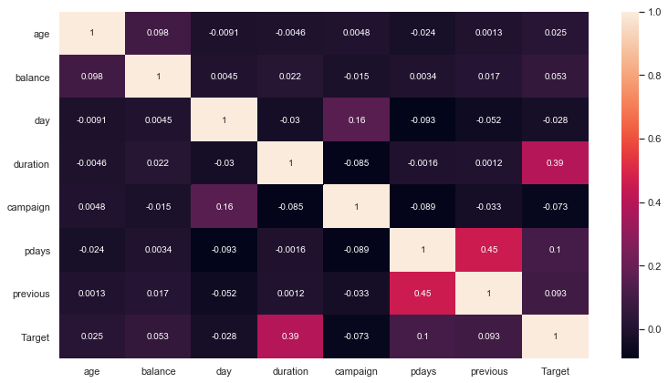

```python
plt.figure(figsize=(13,7))
sns.heatmap(corr,annot=True)
```

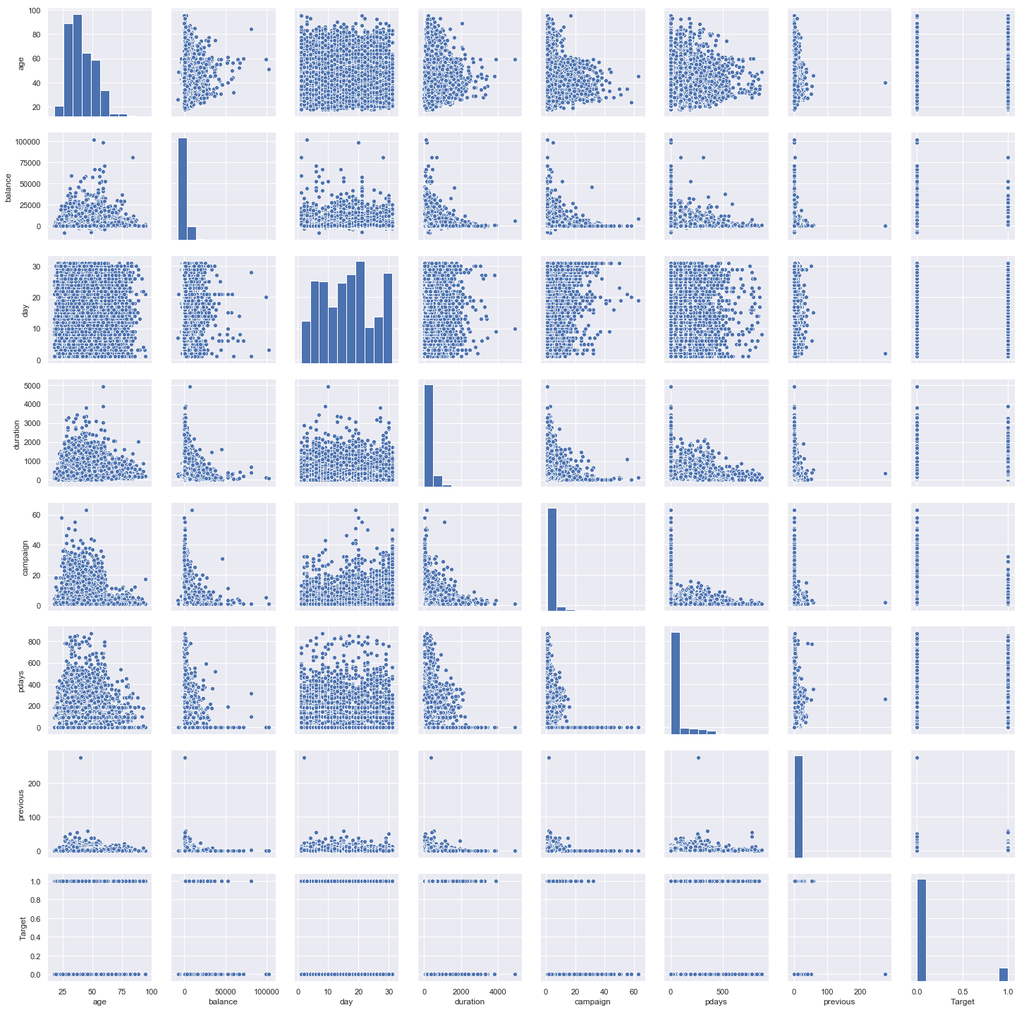

```python
sns.pairplot(data=df)
```

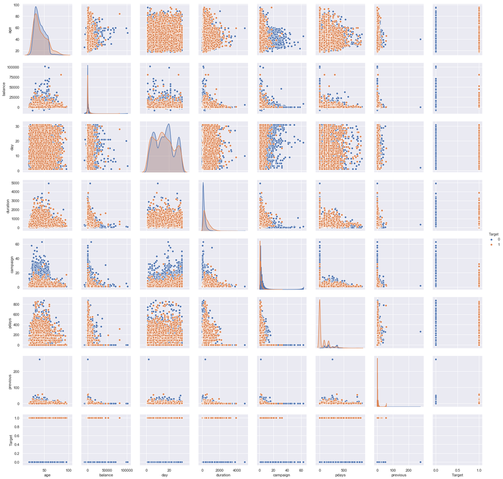

```python
sns.pairplot(data=df,diag_kind="kde",hue="Target")
# People with high balance have low duration of calls, which makes sense as people with less balance are
# more likely to be interested in security term deposits.
# Clients who have been contacted between 1-20 times have subscribe most to term deposit.
```

### 1. Univariate Analysis.

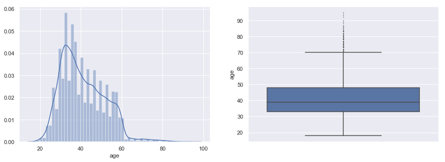

```python
fig,axes = plt.subplots(nrows=1,ncols=2,figsize=(15,5))
sns.distplot(df['age'],ax=axes[0])
sns.boxplot(y=df['age'],fliersize=0.5,ax=axes[1])
plt.show()
# Right skewness and presence of long right tails.
# Maximum customers lie between the age group 30-50
```

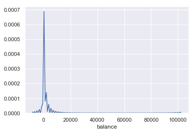

```python
sns.distplot(df['balance'],hist=False)
```

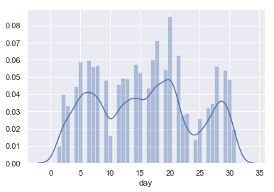

```python
sns.distplot(df['day'])
```

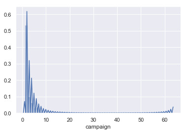

```python
sns.distplot(df['campaign']) #Most number of times people have been contacted between 1-10 range
```

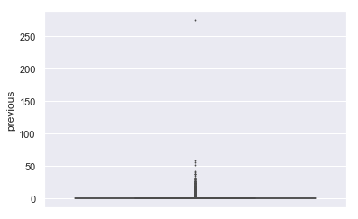

```python
sns.boxplot(y="previous",data=df,fliersize=1) # Presence of outlier, (275)
```

```python
# Removing the above noticed outlier
index = df[df['previous']==275].index
#df.iloc[index]
df.drop(index,inplace=True,axis=0)
```

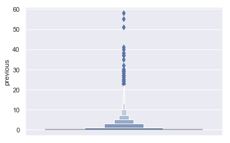

```python
sns.boxenplot(y="previous",data=df) # After removing outlier.
```

```python
df[df['pdays']==-1]['pdays'].count() #Most of the poeple have not been contacted previously
```

```
36954
```

```python
#Cleaning the data by replacing the uncontacted people's pdays value to 0
df.loc[df['pdays']==-1,'pdays']=0
```

```python
df[df['pdays']==0]['pdays'].count() #Replaced -1 by 0
```

```
36954
```

### Creating different balance groups

```python
no_bal = df[df['balance']<=0]
low_bal = df[(df['balance']) & (df['balance']<1000)]
avg_bal = df[(df['balance']>1000 )& (df['balance']<5000)]
high_bal = df[df['balance']>5000]
balance_groups = [len(no_bal),len(low_bal),len(avg_bal),len(high_bal)]
balance_groups
```

```
[7280, 13645, 11784, 2845]
```

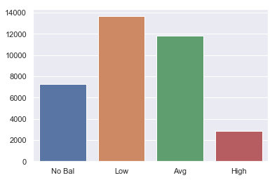

```python
b_group = ['No Bal','Low','Avg','High']
sns.barplot(x=b_group,y=balance_groups)
```

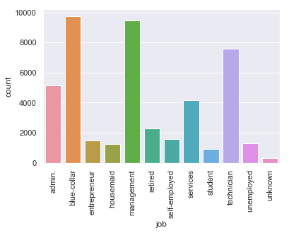

```python
sns.countplot(df['job'])
plt.xticks(rotation=90)
plt.show()
# Maximum number of data is available for blue-collar, management and technician jobs.
```

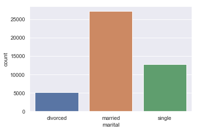

```python
sns.countplot(df['marital']) # The data is biased towards married customers.
```

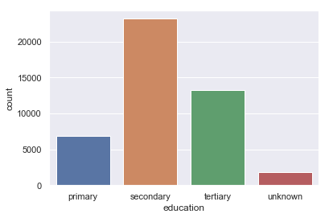

```python
sns.countplot(df['education'])
# Most of the customers belong to the secondary education tier.
```

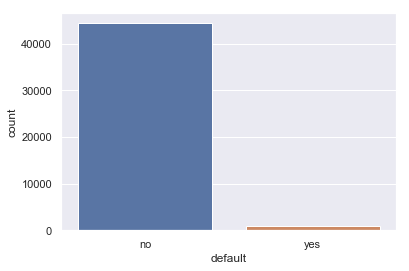

```python
sns.countplot(df['default'])
# Most of the customers do not have credit default.
```

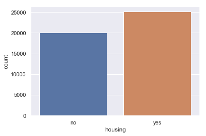

```python
sns.countplot(df['housing'])
# More or less equal number of customers of taken and refused house loans.
```

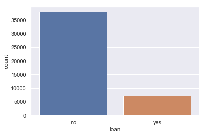

```python
sns.countplot(df['loan'])
# Majority of people have not taken personal loan
```

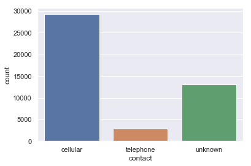

```python
sns.countplot(df['contact'])
# Mostly people have been contacated on cellular medium and least on telephonic medium.
```

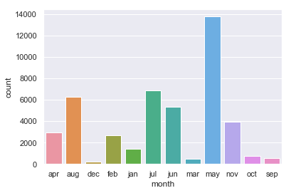

```python
sns.countplot(df['month'])
# Maximum number of people in the previous campaign were contacted in the month of may followed by july.
```

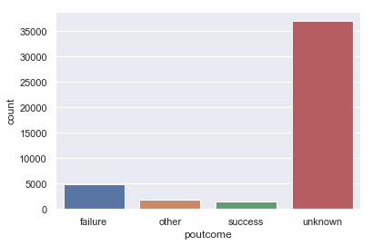

```python
sns.countplot(df['poutcome'])
# Most of the outcome of the previous campaign is still unknown
```

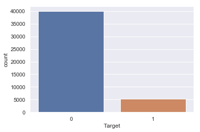

```python
sns.countplot(df['Target'])
# The data is biased towards the non-subscribing term deposit clients.
```

### 2. Bivariate and Multivariate analysis

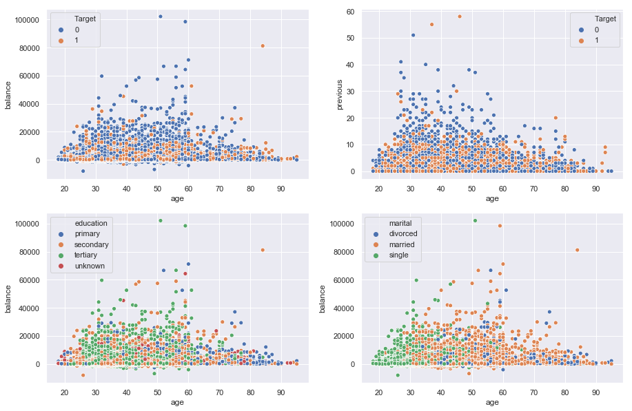

```python
fig,axes = plt.subplots(nrows=2,ncols=2,figsize=(15,10))
sns.scatterplot(x=df['age'],y=df['balance'],hue=df['Target'],ax = axes[0][0])
sns.scatterplot(x=df['age'],y=df['previous'],hue=df['Target'],ax = axes[0][1])
sns.scatterplot(x=df['age'],y=df['balance'],hue=df['education'],ax = axes[1][0])
sns.scatterplot(x=df['age'],y=df['balance'],hue=df['marital'],ax = axes[1][1])
# The subscription is more prelevant in low and medium balance groups.
# Most people have been cintactated within 10 times with few special needs customers who go as high as 58.
```

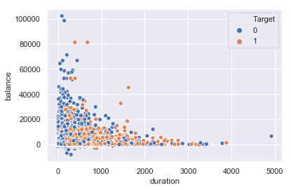

```python
sns.scatterplot(x="duration",y="balance",hue="Target",data=df)
# Least durations in high balance groups and higher durations in low and medium balance groups.
# Low and medium balance groups will be more interested in subscribing to term-deposits.
```

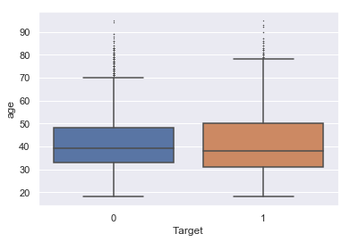

```python
sns.boxplot(x="Target",y="age",data=df,fliersize=0.5)
```

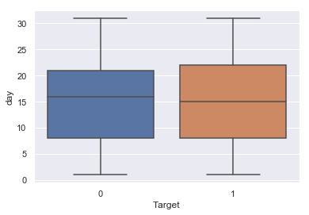

```python
sns.boxplot(x="Target",y="day",data=df,fliersize=0.5)
```

```python
# Creating count variables of different balance groups based on whether they subscribe to term deposit or not.
no_bal_sub = len(no_bal[no_bal['Target']==1])
no_bal_no_sub = len(no_bal[no_bal['Target']==0])

low_bal_sub = len(low_bal[low_bal['Target']==1])
low_bal_no_sub = len(low_bal[low_bal['Target']==0])

avg_bal_sub = len(avg_bal[avg_bal['Target']==1])
avg_bal_no_sub = len(avg_bal[avg_bal['Target']==0])

high_bal_sub = len(high_bal[high_bal['Target']==1])
high_bal_no_sub = len(high_bal[high_bal['Target']==0])
```

```python
data_balance = [{"category":"No Balance",
                "value":no_bal_sub,
                "subscribe":"Subscribed"},
               {"category":"No Balance",
                "value":no_bal_no_sub,
                "subscribe":"Not Subscribed"},

                {"category":"Low Balance",
                "value":low_bal_sub,
                "subscribe":"Subscribed"},
               {"category":"Low Balance",
                "value":low_bal_no_sub,
                "subscribe":"Not Subscribed"},

                {"category":"Avg Balance",
                "value":avg_bal_sub,
                "subscribe":"Subscribed"},
               {"category":"Avg Balance",
                "value":avg_bal_no_sub,
                "subscribe":"Not Subscribed"},

               {"category":"High Balance",
                "value":high_bal_sub,
                "subscribe":"Subscribed"},
               {"category":"High Balance",
                "value":high_bal_no_sub,
                "subscribe":"Not Subscribed"}]

balance_frame = pd.DataFrame(data_balance)
balance_frame
```

|  | category | subscribe | value |
| --- | --- | --- | --- |
| 0 | No Balance | Subscribed | 502 |
| 1 | No Balance | Not Subscribed | 6778 |
| 2 | Low Balance | Subscribed | 1382 |
| 3 | Low Balance | Not Subscribed | 12263 |
| 4 | Avg Balance | Subscribed | 1807 |
| 5 | Avg Balance | Not Subscribed | 9977 |
| 6 | High Balance | Subscribed | 441 |
| 7 | High Balance | Not Subscribed | 2404 |